# Project 1

## Imputing missing values

Calculate and report the total number of missing values in the dataset (i.e. the total number of rows with NAs)

```r
# TRUE = 1 FALSE = 0, so 0 = no missing values
sum(is.na(df$steps))
```

```
## [1] 2304
```

```r
# Merge together df and total steps per day
df_imputed <- merge(df, dfDaily, by = "date")

# 1. Subset the steps by all the rows which are NAs
# 2. Replace that subset with all the sum values which are of the same row
df_imputed$steps[is.na(df_imputed$steps)] <- df_imputed$sum[is.na(df_imputed$steps)]

#reorder columns to match the original dataset
#first comma means keep all rows
df_imputed <- df_imputed[,c("steps", "date", "interval")]
```

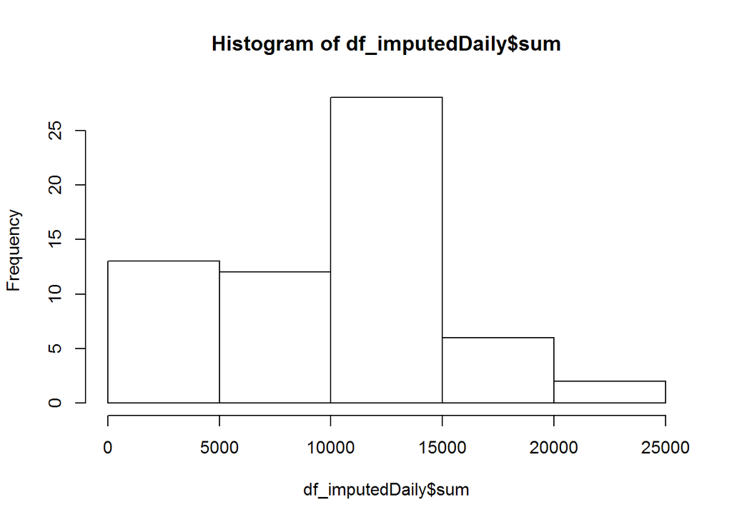

```r
df_imputedDaily <- ddply(df, .(date),summarize,sum=sum(steps, na.rm = TRUE))

hist(df_imputedDaily$sum)
```

```r
mean(df_imputedDaily$sum)
```

```
## [1] 9354.23
```

```r
median(df_imputedDaily$sum)
```

```
## [1] 10395
```

## Are there differences in activity patterns between weekdays and weekends?

- Create a new factor variable in the dataset with two levels – “weekday” and “weekend” indicating whether a given date is a weekday or weekend day.

```r
# Set time system to local, so dates are in english rather than portuguese
Sys.setlocale("LC_TIME", "C")
```

```
## [1] "C"
```

```r
# Create new variable with the day of the week for each obs
df_imputed$day <-weekdays(as.Date(df$date))

# Factor days into two levels (`weekday` and `weekend`)
weekdays1 <- c('Monday', 'Tuesday', 'Wednesday', 'Thursday', 'Friday')
df_imputed$day_factor <- factor((df_imputed$day %in% weekdays1), levels= c(FALSE, TRUE), labels=c('weekend', 'weekday'))
```

- Make a panel plot containing a time series plot (i.e. type = “l”) of the 5-minute interval (x-axis) and the average number of steps taken, averaged across all weekday days or weekend days (y-axis).

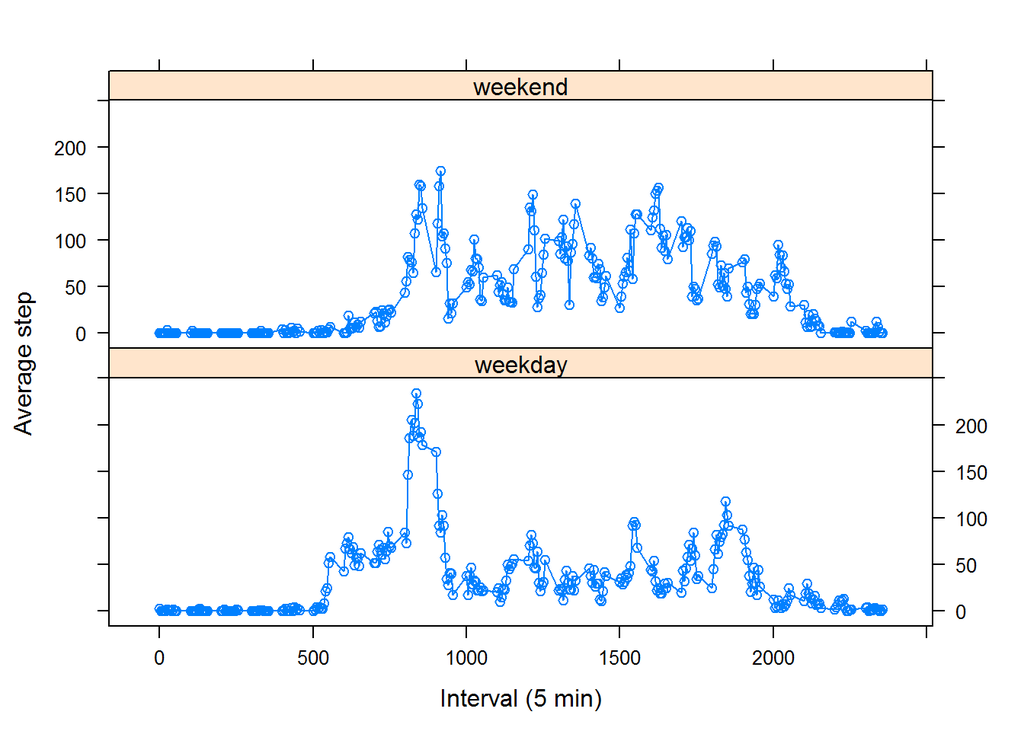

```r
library(dplyr)
adav <- df_imputed %>%
    group_by(interval, day_factor) %>%
    summarize(mean=mean(steps,na.rm=TRUE)) %>%
    arrange(day_factor)

library(lattice)
xyplot (adav$mean ~ adav$interval| adav$day_factor, type="o",
        layout=c(1, 2), as.table=T, xlab="Interval (5 min)", ylab="Average step")
```